# R Steinschlag_Datavisualization

## Introduction

In this R notebook we are going to explore the data of the “Steinschlag-Challeng, HS19C4”. The Idea behind the project is to calculate the probablilty of a death through a rockfall at a slope above a road in Graubünden, Switzerland. The Challenge itself can be found under the following link: [Steinschlag Challenge](https://ds-spaces.technik.fhnw.ch/steinschlag/)

This notebook is used to visualize the data through numerous plots. The calculation of the probability will be calculated in a simulation and the final findings of this exploration will be published later on a website.

```r
library(tidyverse)
library(grid)
library(gridExtra)
library(chron)
library(psych)
library(knitr)
library(MASS)
library(fitdistrplus)
library(propagate)
library(evd)
library(reticulate)
library(sys)
library(janitor)
library(lubridate)
# Go to Working Directory
getwd()
```

```
## [1] "C:/Users/Roman Studer/Dropbox/01_SG DS/Challenges/Steinschlag/Steinschlag_git_respository/steinschlag"
```

```r
# Import Datasets:
out_1 <- read.csv("out_1.csv", sep = ";")
out_2 <- read.csv("out_2.csv", sep = ";")
traffic_density <- read.csv("trafficdensity_per_hour.csv", sep = ";")
```

### 1. Data transformation

#### 1.1 `rename` CSV-Colums

```r
out_1 <- rename(out_1, mass = Masse..kg., speed = Geschwindigkeit..m.s., time = Uhrzeit, date = Datum, energy = Kin_Energy..kJ.)
out_2 <- rename(out_2, mass = Masse..kg., speed = Geschwindigkeit..m.s., time = Uhrzeit, date = Datum, energy = Kin_Energy..kJ.)
```

#### 1.2 Transform ‘traffic_density’ set

The traffic_density data is scaled to 217.0795 percent and needs to be scaled down to 100 percent. Because of that we divide the percentile column by 2.170795

```r
sum(traffic_density$percentile)
```

```
## [1] 217.0795
```

```r
traffic_density <- mutate(traffic_density, percentile = percentile/2.170795 )
sum(traffic_density$percentile)
```

```
## [1] 100
```

#### 1.3 Transform time column into datetime-type

The code below could be used to transform the time column of our dataset into a datetime type.

```r
# out_1 <- transform(out_1, time = as.times(time))
# out_2 <- transform(out_1, time = as.times(time))
```

#### 1.4 Combine Datasets

```r
#Now that we have two datasets with the same column names we can combine them into one:
data_bind <- rbind(out_1, out_2)
```

#### 1.5 Delete rows with mistakes

In the dataset we see that one event has a mass of zero. Either the rock has a mass below 1 kg or the value is a mistake in the dataset. Because we can’t now what is true we are going to work with a subset of our original data that doesn’t contain the row with a mass value of zero:

```r
rockfall <- subset(data_bind, mass != 0)
```

#### 1.6 Statistic values

Here one can see some statistical values such as mean, standard deviation (sd), median, min and max value.

```r
mass <- dplyr::select(rockfall, mass)

stat_data <- dplyr::select(describe(dplyr::select(rockfall, mass, speed, energy)), mean, sd, median, min, max)
stat_data
```

|  | mean | sd | median | min | max |
| --- | --- | --- | --- | --- | --- |
| mass | 463.86869 | 628.13302 | 236.00000 | 3.00000 | 3104.0000 |
| speed | 17.92525 | 14.02122 | 10.00000 | 3.60000 | 46.5000 |
| energy | 40.45041 | 60.39208 | 19.06254 | 0.46464 | 394.7964 |

## 2. Datavisualization

### 2.1 Histogramms

#### 2.1.1 Mass

The code below plots a histogramm of the “mass”-column in our dataset. Here we see that most of the rocks have a mass below 500kg. This is intersting because we would need more than four rocks of this size to break through the security-net. If we look at other variables we see that we only have two days with this many rockfalls.(The next histogramms are plottet with the same code, just with other variables)

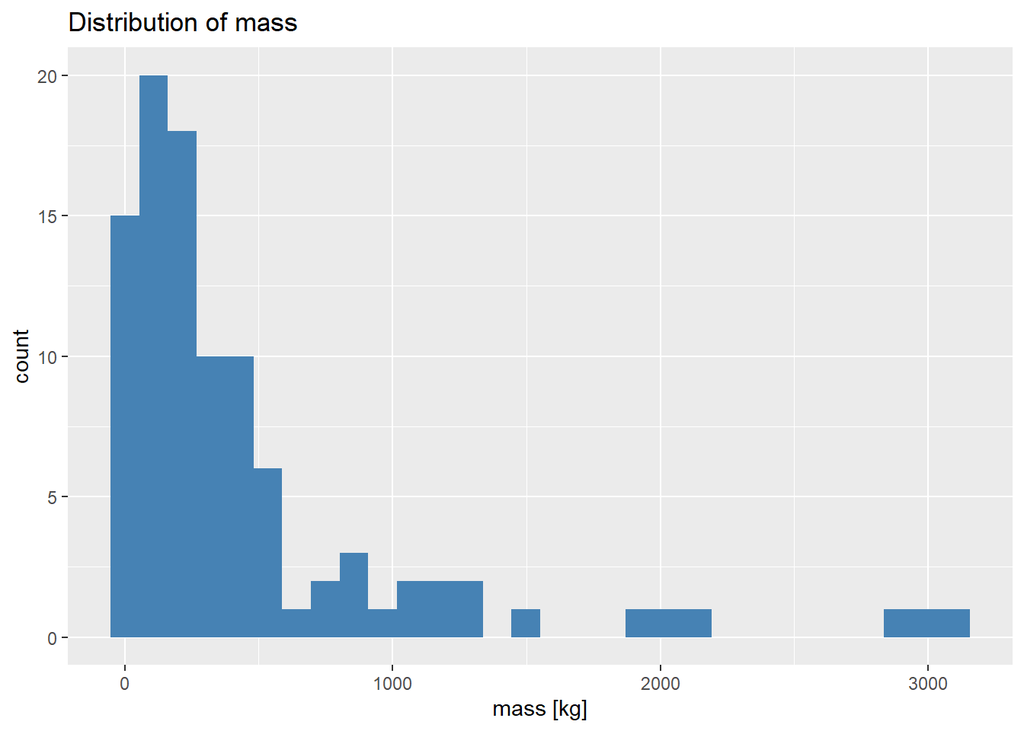

```r
ggplot(data = rockfall)+
  # Plot histogram of the mass distribution in the rochfall dataset:
  geom_histogram(mapping = aes(x =mass), fill = "steelblue")+
  labs(title = "Distribution of mass", x='mass [kg]')
```

#### 2.1.2 Energy

If we plot the energy (in kilojoule) we can see that a big part of our rocks have a very low energy and we can even see that over 15 have a value of 0 on the plot. This is because we have multiple rocks that don’t reach an energy of >10kJ.

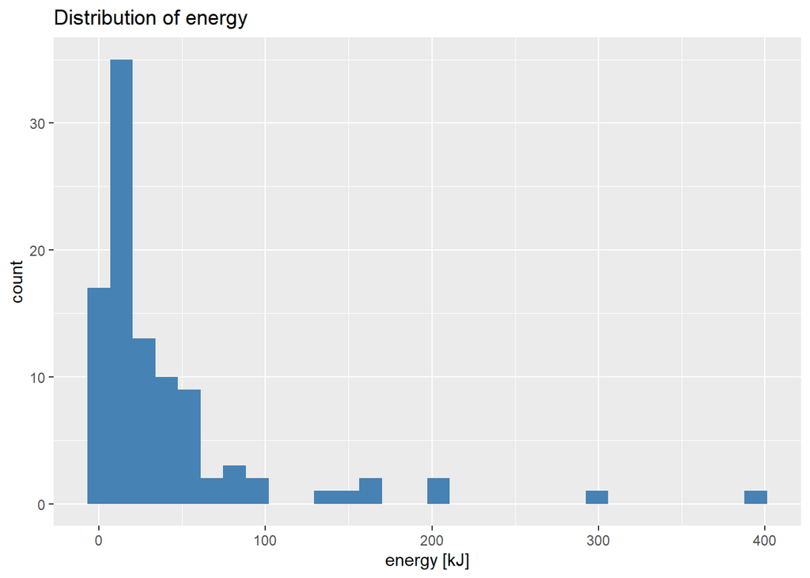

```r
ggplot(data = rockfall)+
  geom_histogram(mapping = aes(x = energy),fill = "steelblue")+
  labs(title = "Distribution of energy", x='energy [kJ]')
```

#### 2.1.3 Speed

Here we see that we have a maximum speed of around 46 meters per second. The speed is also split into two groups which indicates shows us the that the two places where rockfalls occur are on a diffrent hight. Later in this notebook I’m going to plot the relationship of the mass and speed.

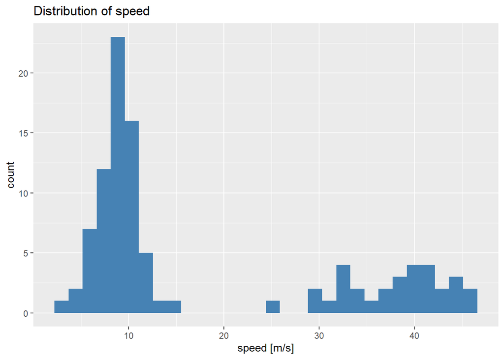

```r
ggplot(data = rockfall)+
  geom_histogram(mapping = aes(x = speed),fill = "steelblue")+
  labs(title = "Distribution of speed", x='speed [m/s]')
```

#### 2.1.4 Rockfalls per Hour

As soon as we group the events to the hour they occur we see that we have an increase of rockfalls towards noon and a slower decrease after noon. The most rocks fall at 12 O’clock. At this time the traffic will be high as well, wich means that we should include the traffic density in to our probability calculation.

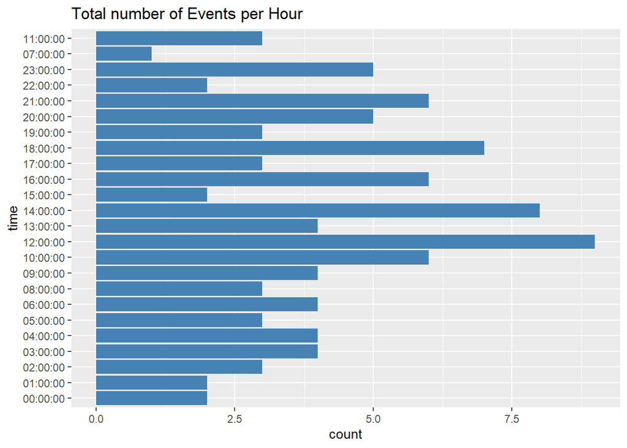

```r
# count <- select(rockfall, time = n())
ggplot(data = rockfall)+
  geom_histogram(mapping = aes(x = time),fill = "steelblue", stat="count")+
  coord_flip()+
  labs(title = "Total number of Events per Hour")
```

### 2.2 Graphs

#### 2.2.1 False readouts

Something interesting we found was that the binding of the two datasets can lead to some errors in the datavisualization. The first two graphs below show us how the mass corresponds to the energy of a rockfall. Which seems to be quite linear. This makes sense so far. As soon as we plot the same two variables out of the combined dataset(`rockfall`) we get a spike around 300 to 500 kg. This doesn’t seem to make sense. But this tells us that the rocks of the two dataset have to fall from diffrent hights. Because only a greater speed in one dataset would explain the rise of energy in the mass. This also tells us that we can’t use the data as a combined dataset and should work with the two seperate datasets. Especially to fit a distribution to the data.

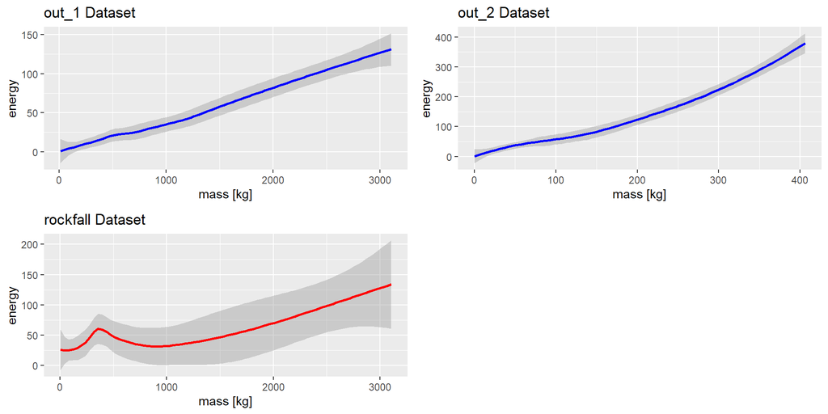

```r
ggplot(data = out_1)+
  geom_smooth(mapping = aes(x = mass, y = energy), color = "blue") +
  ggtitle("out_1 Dataset")+
  labs(x='mass [kg]')-> p1

ggplot(data = out_2)+geom_smooth(mapping = aes(x = mass, y = energy), color = "blue") +           ggtitle("out_2 Dataset")+
  labs(x='mass [kg]')-> p2

ggplot(data = rockfall)+
  geom_smooth(mapping = aes(x = mass, y = energy), color = "red") +
  ggtitle("rockfall Dataset")+
  labs(x='mass [kg]')-> p3
grid.arrange(p1, p2, p3, ncol = 2, nrow = 2)
```

#### 2.2.2 Traffic density per hour

The following graph shows the trafiic density on roads in switzerland per hour. This data will be used to calculate the probability of a hit combined with the traffic density. This data has been pulled from the swiss institute for statistics and contains the information of the average of cars passing through per hour. This dataset is from 2015 but is the latest data with this information.

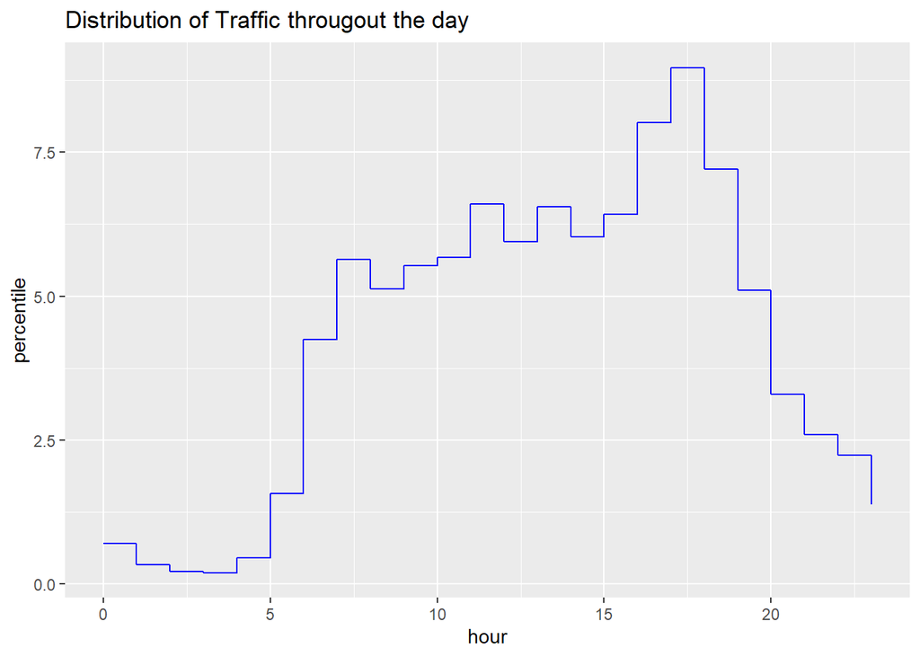

```r
ggplot(data = traffic_density)+
  geom_step(mapping = aes(x = hour, y = percentile), color = "blue")+
  ggtitle("Distribution of Traffic througout the day")
```

### 2.3 Scatterplot

This visualization shows us how the mass and the speed of our rocks corellate. Here we can also see a clear diffrence between the two dataset. (The Energy is also visible as the size and color of the dots. A darker color means less energy.)

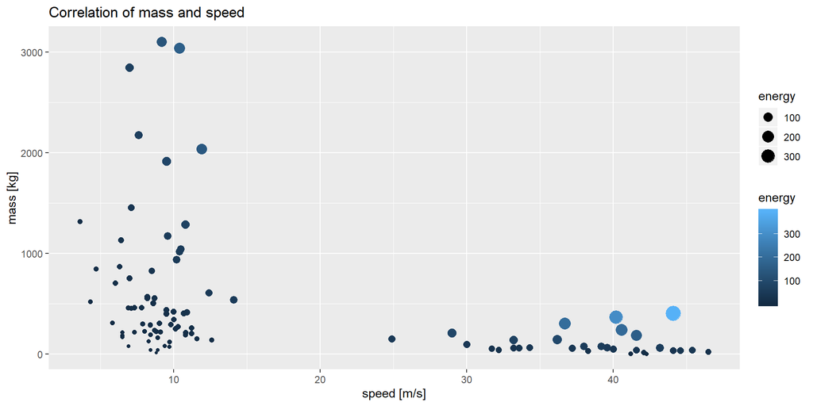

```r
ggplot(data = rockfall, aes(x = speed, y = mass, size = energy, color = energy ))+
  geom_point()+
  ggtitle("Correlation of mass and speed")+
  labs(x = 'speed [m/s]', y = 'mass [kg]')
```

### 3. Calculation of the probability of a car getting hit by a rock under the assumption that a rock could break trough the securitynet.

Given:

- Rock breaks through net
- Mass of stone is over two tonnes
- Trafficdensity is 1200 cars per day, without any trafficjam
- Speed of the cars: 16.66 m/s
- Average size of car:
  - Length: 4.4m
  - Width: 1.8m

Assumptions:

- A car getting hit by stone automaticaly causes a deady accident
- Higth of car wont be part of the calculation
- Speed of the rock wont be part of the calculation
- Width of rock is on average about 1 meter

#### 3.1 Probability of Rockfall per Hour

To calculate the expected value at which hour a rockfall takes place we are going to take a look at the Histogram “Rockfalls per Hour” (2.1.4) which shows us the distribution throughout the day. To count the falls per hour we are going to use the function `count` and divide these numbers by 0.99 to get the percentage which also equals the expected value of an event occuring at that hour.

```r
exp_rock <- count(rockfall, time)

(exp_rock <- mutate(exp_rock,
                 expected_value = n/0.99/100))
```

| time | n | expected_value |
| --- | --- | --- |
| 00:00:00 | 2 | 0.02020202 |
| 01:00:00 | 2 | 0.02020202 |
| 02:00:00 | 3 | 0.03030303 |
| 03:00:00 | 4 | 0.04040404 |
| 04:00:00 | 4 | 0.04040404 |
| 05:00:00 | 3 | 0.03030303 |
| 06:00:00 | 4 | 0.04040404 |
| 08:00:00 | 3 | 0.03030303 |
| 09:00:00 | 4 | 0.04040404 |
| 10:00:00 | 6 | 0.06060606 |

[output cut: 14 more lines]

#### 3.2 Total Time a Car is in Danger

The next step is to calculate the time a car is in the dangerous zone. We now that the cars drive with 60 km/h and have an average length of 4.4 meters. Because the car can be hit in the front or in the back we need to take double the length plus the width of the stone as our danger zone. Which comes out to be 9.8 meters. With this we calculate the following:

```python
#Time to drive a distance of 9.8 meters (2* the length of cars + length of rockd)

speed = 60/3.6 #conversion form km/h to m/s

#time will be calculatet with the formula "distance/speed"
T_single_car = 9.8/speed
print("Time to drive 9.8m :", T_single_car, "seconds")
```

```
## Time to drive 9.8m : 0.588 seconds
```

Now that we have the time a car is in the “danger”-zone we can calculate the total time (seconds in hour) in which cars are in danger of getting hit by a rock breaking though the net. For this we are going to create a new list called “car_per_hour” which will contain the total count of cars driving through, the total time of cars being in danger and the percentage of a car driving through this zone at this hour.

After that we can calculate the expected value of a car getting hit by simply multiplying the probability of a rock falling at this hour and the probability of a car being in the dangerous zone at this hour. We calculate an expected value of 0.009241006 or 0.924% for this event to happen.

```r
# calculate cars passing though per hour
car_per_hour <- mutate(traffic_density,
                       cars_passing = percentile * 12,
                       time_in_danger = cars_passing * 0.588,
                       exp_car = time_in_danger/3600)


(expected_value_car <- mutate(exp_rock, time, n, expected_value,
                          car_passing_hour = car_per_hour$cars_passing,
                          t_car_in_danger = car_per_hour$time_in_danger,
                          exp_car_per_hour = car_per_hour$exp_car,
                          t_exp_per_hour = expected_value * car_per_hour$exp_car))
```

| time | n | expected_value | car_passing_hour | t_car_in_danger | exp_car_per_hour | t_exp_per_hour |
| --- | --- | --- | --- | --- | --- | --- |
| 00:00:00 | 2 | 0.02020202 | 8.335937 | 4.901531 | 0.0013615364 | 2.750579e-05 |
| 01:00:00 | 2 | 0.02020202 | 3.937034 | 2.314976 | 0.0006430489 | 1.299089e-05 |
| 02:00:00 | 3 | 0.03030303 | 2.525351 | 1.484906 | 0.0004124740 | 1.249921e-05 |
| 03:00:00 | 4 | 0.04040404 | 2.331882 | 1.371147 | 0.0003808741 | 1.538885e-05 |
| 04:00:00 | 4 | 0.04040404 | 5.418837 | 3.186276 | 0.0008850767 | 3.576067e-05 |
| 05:00:00 | 3 | 0.03030303 | 18.774211 | 11.039236 | 0.0030664544 | 9.292286e-05 |
| 06:00:00 | 4 | 0.04040404 | 50.982823 | 29.977900 | 0.0083271945 | 3.364523e-04 |
| 08:00:00 | 3 | 0.03030303 | 67.687066 | 39.799995 | 0.0110555541 | 3.350168e-04 |
| 09:00:00 | 4 | 0.04040404 | 61.521833 | 36.174838 | 0.0100485661 | 4.060027e-04 |
| 10:00:00 | 6 | 0.06060606 | 66.382652 | 39.032999 | 0.0108424997 | 6.571212e-04 |

[output cut: 14 more lines]

```r
total_in_danger <- dplyr::select(expected_value_car, exp_car_per_hour)
```

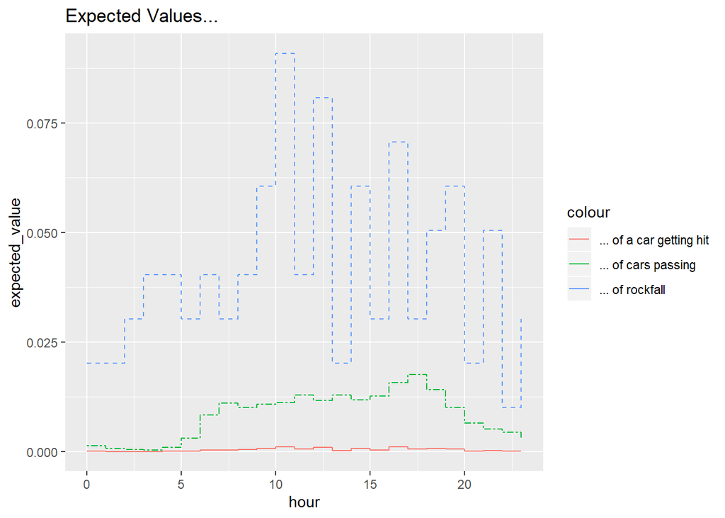

```r
expected_value_car <- mutate(expected_value_car,
hour = traffic_density$hour)

ggplot(data = expected_value_car)+
  geom_step(mapping = aes(x = hour, y = expected_value, color = '... of rockfall'), linetype = "dashed")+
  geom_step(mapping = aes(x = hour, y = exp_car_per_hour, color = "... of cars passing"), linetype = "twodash")+
  geom_step(mapping = aes(x = hour, y = t_exp_per_hour, color = "... of a car getting hit"))+
  labs(title='Expected Values...')
```

The expected value of a car getting hit by rockfall at the assumption that a rockfall, capable of breaking through the net, occurs is:

```r
# the probability of a car getting hit by a rock incase it breaks through the security net.
e_car_hit <- sum(expected_value_car$t_exp_per_hour)
e_car_hit
```

```
## [1] 0.009241006
```

### 4. Net-Energy

#### 4.1 Net-Energy Distribution

We aim to find an adequate density and distribution function based on the energy of both given data-sets `out_1`" and `out_2`" to be able to calculate the $P(X \geq x | stone falls into the net)$ where $X$ is a continuous variable of the calculated energy $energy[kJ] = \frac{0.5 * m * v^2}{1000}$. Since there is just one net and the energy distribution of the net doesn’t care from wich source the rock falls, both data-sets are considered to evaluate an appropriate density funciton.

To get an imagination of how the data might be distributed, we plot the density of the observed energy with a histogramm.

The comparison of different density functions with the approximated function of the observed energy shows how well each function fit the actual values of the rockfall.

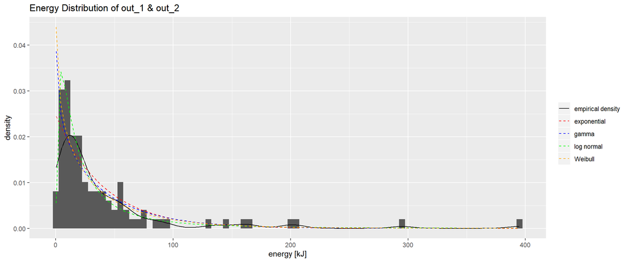

```r
e_fit <- fitdistr(rockfall$energy, "exponential")
g_fit <- fitdistr(rockfall$energy, "gamma")
lnrm_fit <- fitdistr(rockfall$energy, "lognormal")
w_fit <- fitdistr(rockfall$energy, "weibull")

ggplot(rockfall, aes(energy)) +
  geom_histogram(aes(y = ..density..), binwidth = 5) +
  geom_line(stat = "density", aes(color = "empirical density", linetype = "empirical density")) +
  ggtitle("Energy Distribution of out_1 & out_2") +
  stat_function(fun = dexp, args = list(e_fit$estimate[1]),
                aes(color = "exponential", linetype = "exponential")) +
  stat_function(fun = dgamma, args = list(g_fit$estimate[1], g_fit$estimate[2]),
                aes(color = "gamma", linetype = "gamma")) +
  stat_function(fun = dlnorm, args = list(lnrm_fit$estimate[1], lnrm_fit$estimate[2]),
                aes(color = "log normal", linetype = "log normal")) +
  stat_function(fun = dweibull, args = list(w_fit$estimate[1], w_fit$estimate[2]),
                aes(color = "Weibull", linetype = "Weibull")) +
  scale_color_manual(name = "",
                     values = c("empirical density" = "black",
                                "exponential" = "red",
                                "gamma" = "blue",
                                "log normal" = "green",
                                "Weibull" = "orange"),
                     breaks = c("empirical density",
                                "exponential",
                                "gamma",
                                "log normal",
                                "Weibull")) +
  scale_linetype_manual(name = "",
                        values = c("empirical density" = "solid",
                                   "exponential" = "dashed",
                                   "gamma" = "dashed",
                                   "log normal" = "dashed",
                                   "Weibull" = "dashed"),
                        breaks = c("empirical density",
                                   "exponential",
                                   "gamma",
                                   "log normal",
                                   "Weibull")) +
  labs(x = "energy [kJ]")
```

#### 4.2 Net-Energy Density Function Evaluation

We figured out that the log normal distribution seems to have a very good fit on the energy distribution on the net. The comparison shows, that the exponential, gamma, and weibull distribution doesn’t fit very well in regards to the extreme values. It is important to mention that each data point does not have a connection as one can see in the QQ-plot. But it helps to get a better overview of the data points.

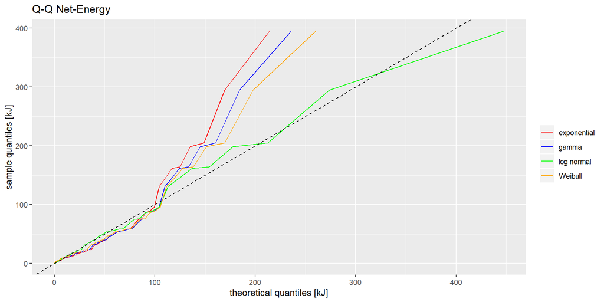

```r
ggplot(rockfall, aes(sample = energy)) +
  stat_qq(distribution = qexp,
          dparams = list(e_fit$estimate[1]),
          geom = "line",
          aes(color = "exponential")) +
  stat_qq(distribution = qgamma,
          dparams = list(g_fit$estimate[1], g_fit$estimate[2]),
          geom = "line",
          aes(color = "gamma")) +
  stat_qq(distribution = qlnorm,
          dparams = list(lnrm_fit$estimate[1], lnrm_fit$estimate[2]),
          geom = "line",
          aes(color = "log normal")) +
  stat_qq(distribution = qweibull,
          dparams = list(w_fit$estimate[1], w_fit$estimate[2]),
          geom = "line",
          aes(color = "Weibull")) +
  geom_abline(slope = 1, intercept = 0, linetype = "dashed") +
  scale_color_manual(name = "",
                     values = c("exponential" = "red",
                                "gamma" = "blue",
                                "log normal" = "green",
                                "Weibull" = "orange"),
                     breaks = c("exponential",
                                "gamma",
                                "log normal",
                                "Weibull")) +
  labs(title = "Q-Q Net-Energy", x = "theoretical quantiles [kJ]", y = "sample quantiles [kJ]")
```

#### 4.3 Net-Energy Cumulative Distribution Function

Here one can see that the cumulative distribution of the log normal function matches the empiric values best.

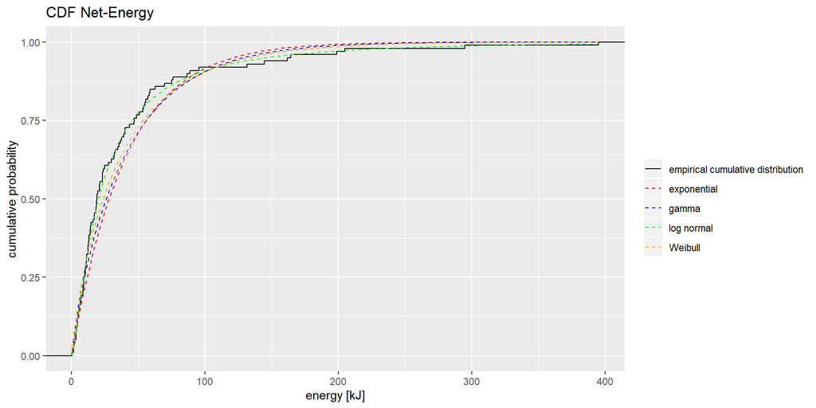

```r
ggplot(rockfall, aes(energy)) +
  stat_ecdf(aes(color = "empirical cumulative distribution",
                linetype = "empirical cumulative distribution")) +
  stat_function(fun = pexp, args = list(e_fit$estimate),
                aes(color = "exponential", linetype = "exponential")) +
  stat_function(fun = pgamma, args = list(g_fit$estimate[1], g_fit$estimate[2]),
                aes(color = "gamma", linetype = "gamma")) +
  stat_function(fun = plnorm, args = list(lnrm_fit$estimate[1], lnrm_fit$estimate[2]),
                aes(color = "log normal", linetype = "log normal")) +
  stat_function(fun = pweibull, args = list(w_fit$estimate[1], w_fit$estimate[2]),
                aes(color = "Weibull", linetype = "Weibull")) +
  scale_color_manual(name = "",
                     values = c("empirical cumulative distribution" = "black",
                                "exponential" = "red",
                                "gamma" = "blue",
                                "log normal" = "green",
                                "Weibull" = "orange"),
                     breaks = c("empirical cumulative distribution",
                                "exponential",
                                "gamma",
                                "log normal",
                                "Weibull")) +
  scale_linetype_manual(name = "",
                        values = c("empirical cumulative distribution" = "solid",
                                   "exponential" = "dashed",
                                   "gamma" = "dashed",
                                   "log normal" = "dashed",
                                   "Weibull" = "dashed"),
                        breaks = c("empirical cumulative distribution",
                                   "exponential",
                                   "gamma",
                                   "log normal",
                                   "Weibull")) +
  labs(title = "CDF Net-Energy", x = "energy [kJ]", y = "cumulative probability")
```

#### 4.4 Net-Energy Log-Norm Distribution Validation

To be sure, we test the sample if it is log normal distributed. We assume $(H_0)$ that our data is log normal distributed with significant level $95\%$. $H_1$ is that the energy of the data set is not log normal distributed. Therefore, we compare 20 smples of random generated log normal distributed quantiles vs. the theoretical quantiles. If there is a similar QQ-plot compared to the plot with the actual energy data, then we can assume that the energy of the rockfall is log-normal distributed.

The comparison of the artificial created data sample and the data set of the energy let us assume, not to deny $H_0$. For this reason, we can transform the energy values with the $ln(x)$ to get a normal distribution in order to compute the probability with the normal distribution function.

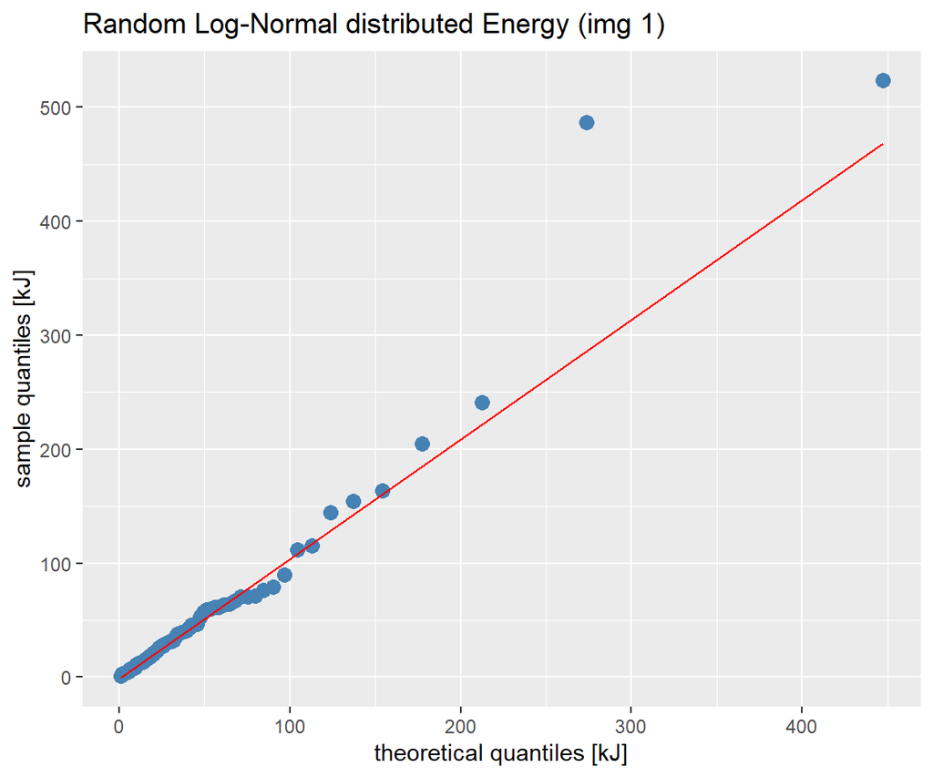

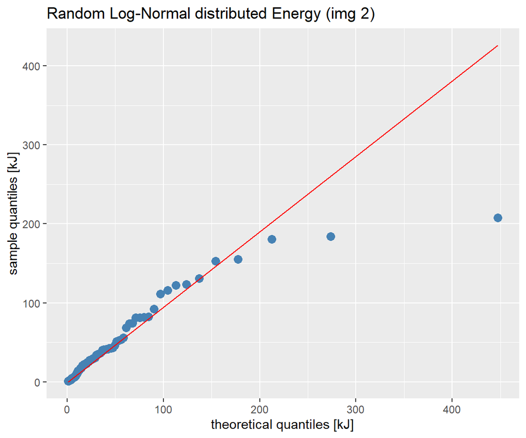

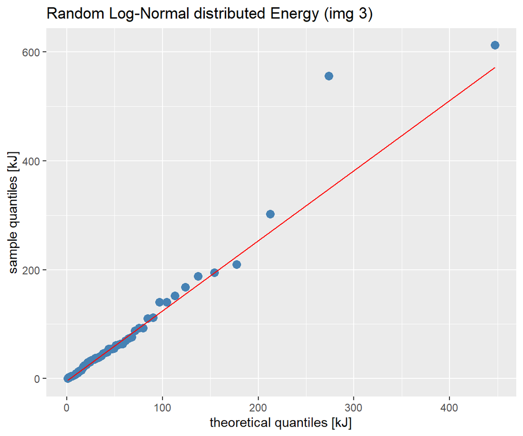

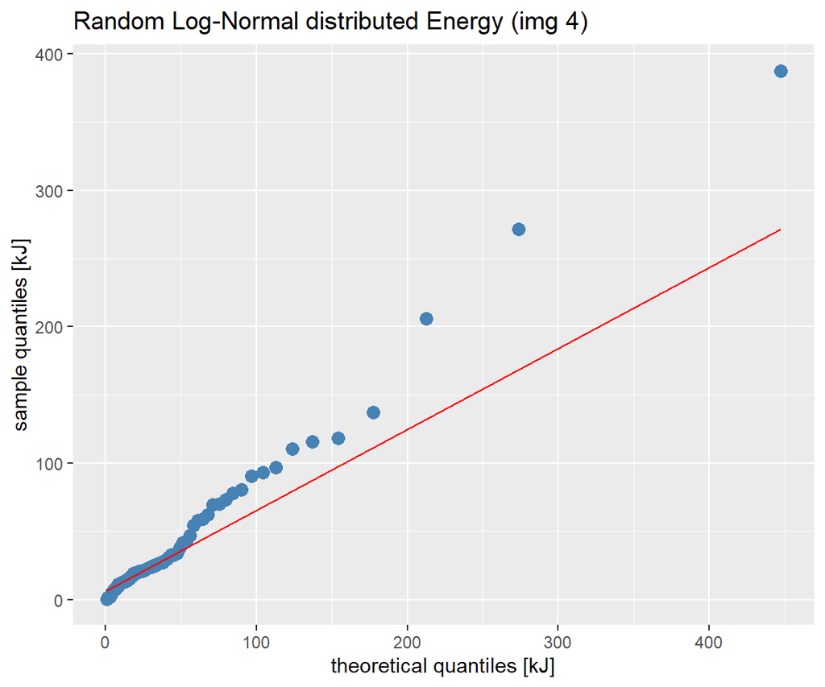

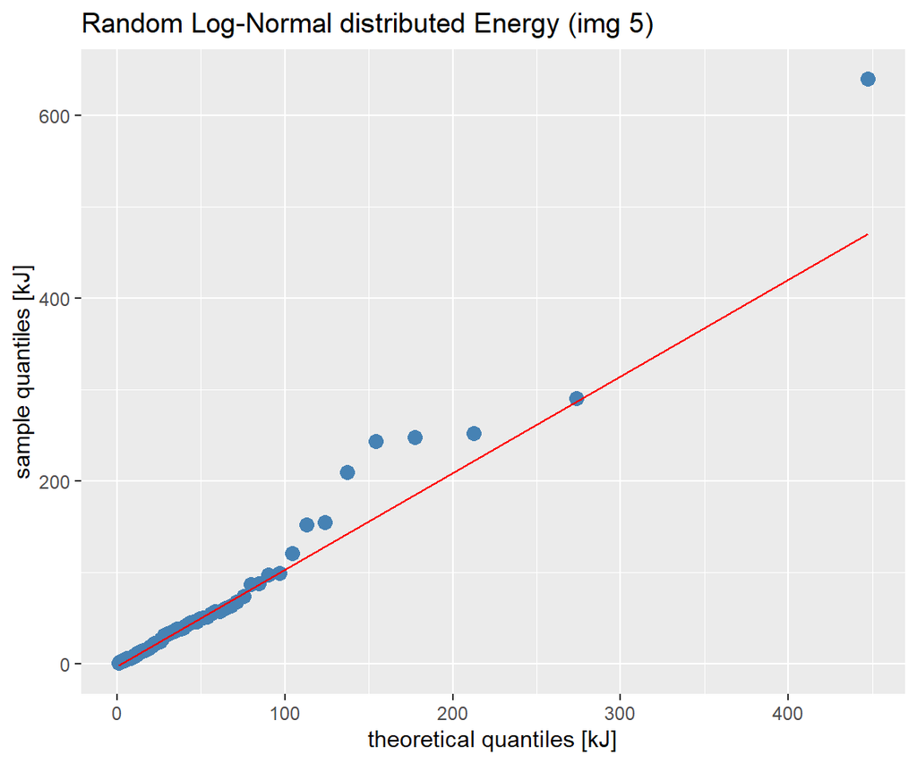

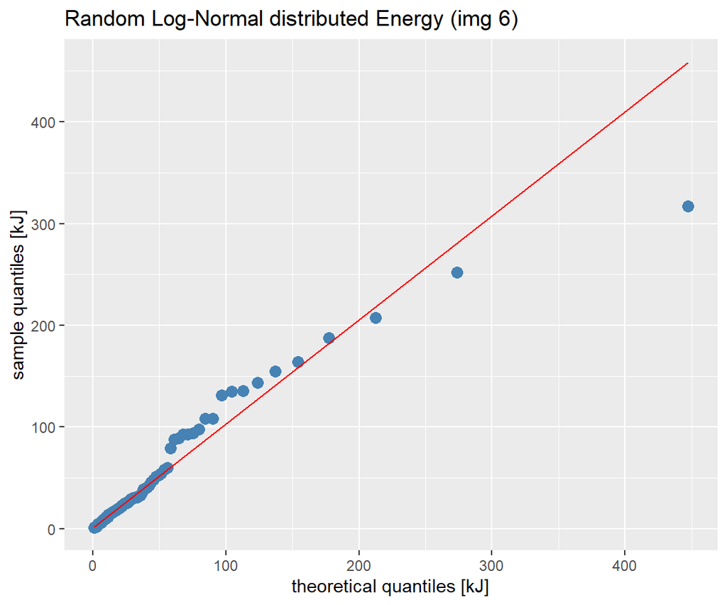

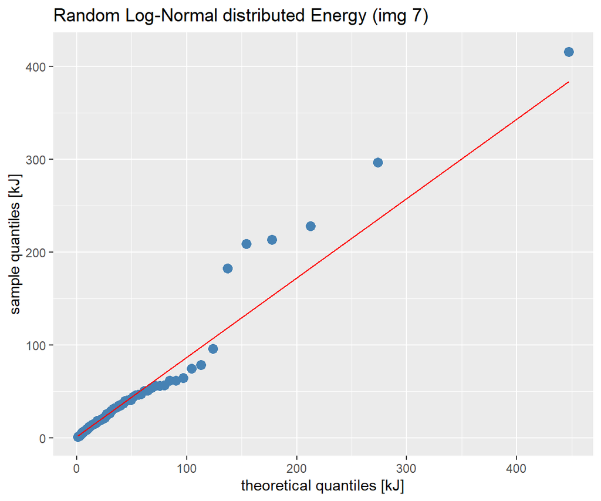

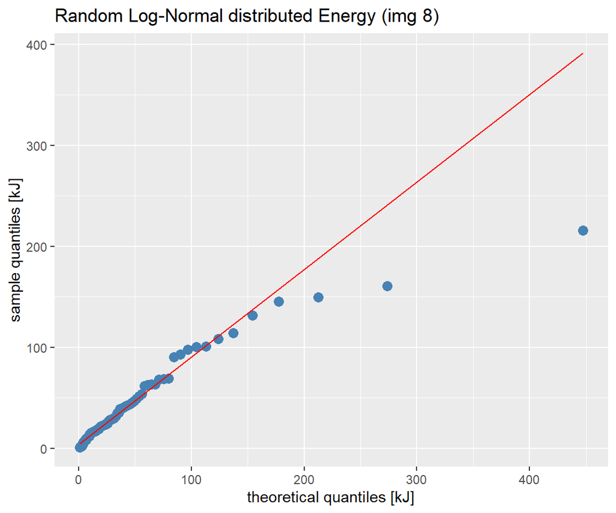

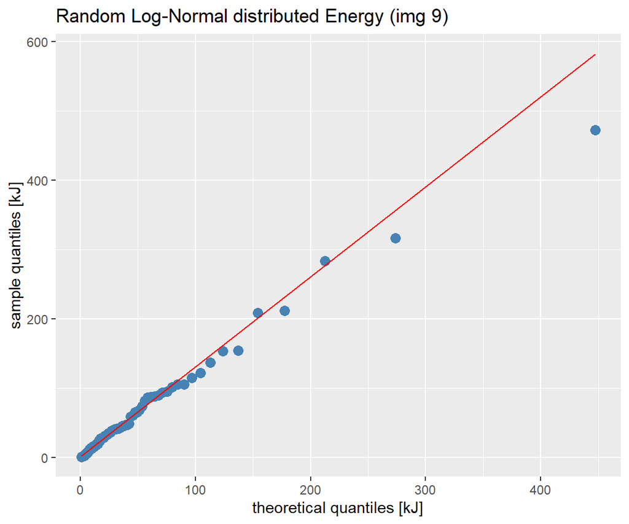

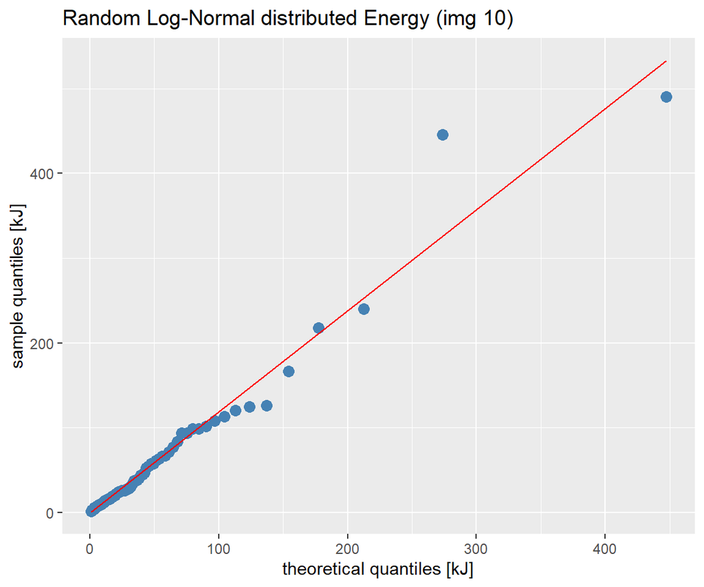

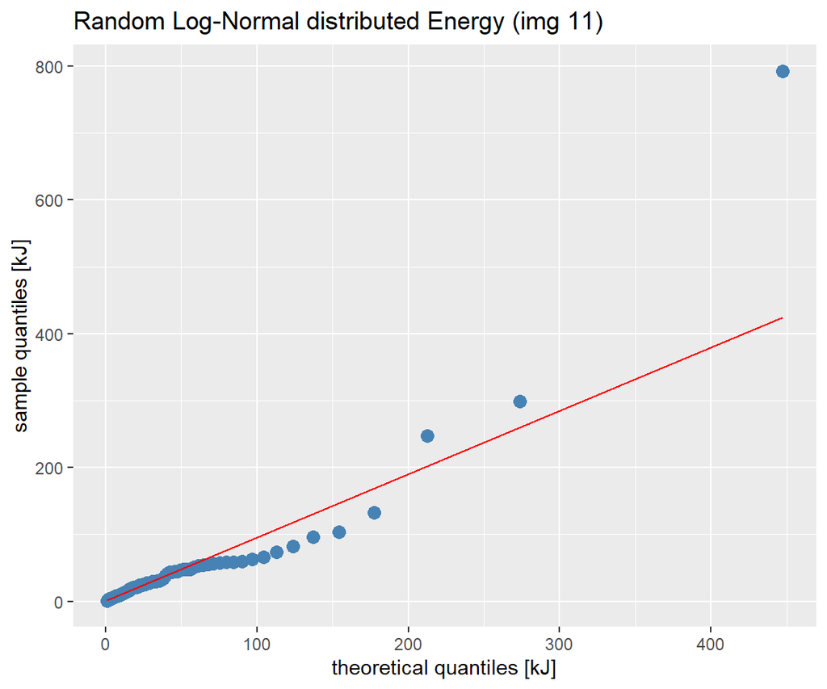

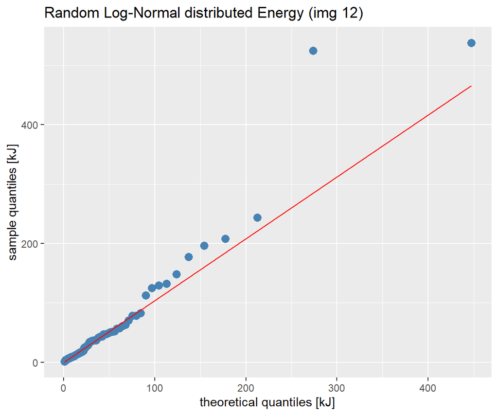

[8 more figures not shown]

```r
rows <- 20
cols <- length(rockfall$energy)
random_dlnorm_matrix <- matrix(nrow = rows, ncol = cols)
for (i in 1:rows){
  random_dlnorm_matrix[i,] <- c(rlnorm(cols, meanlog = lnrm_fit$estimate[1], sdlog = lnrm_fit$estimate[2]))
}
for (j in 1:rows){
  p <- ggplot2::qplot(sample = random_dlnorm_matrix[j,], geom = "blank") +
    stat_qq(distribution = qlnorm, dparams = list(lnrm_fit$estimate[1], lnrm_fit$estimate[2]), color = "steelblue", size = 3) +
    stat_qq_line(distribution = qlnorm, dparams = list(lnrm_fit$estimate[1], lnrm_fit$estimate[2]), color = "red") +
    labs(title = paste0("Random Log-Normal distributed Energy (img ", j, ")"), x = "theoretical quantiles [kJ]", y = "sample quantiles [kJ]")
  print(p)
}
```

#### 4.5 Probability of a Rockfall in a certain Energy Interval

Assuming to have a log normal distribution, we are now able to calculate the probability $P(500 \leq x \leq 1000 | A)$ and $P(x \geq 1000 | A)$ of an interval where $A$ is the condition that a rock falls into the net. $P(0 \leq x < 500 | A)$ is not interesting since a rock with energy $x < 500$ is never strong enough to break through the net. First we compute the natural logarithm of each value on the rockfall energy set $ln(x_i)$ To be able to calculate the probability, the log normal distribution needs $meanlog$ and the $sdlog$ of the distribution, which can be calculated from the logarithmized values of the energy data set.

Now we can take the cumulative distribution function of normal distribution ${\displaystyle F(x)=\int _{-\infty }^{x}{\frac {1}{\sqrt {2\pi }*\sigma}}e^{-\frac{1}{2}(\frac{t-\mu}{\sigma})}\,dt}$ if we transform each energy values with the natural logarithm. To calculate e.g. $P(x \geq 1000 | A)$ we are now able to calculate the area between $0$ and $ln(1000)$ with the normal distribution if we take $\mu = meanlog$, $\sigma = sdlog$ and then subtract the value from $1$ to get the area after $1000 kJ$.

```r
#fitDistr(rockfall$energy, nbin = 99, plot = "qq") ~5min
prob_lnorm <- stats::plnorm(c(500, 1000), meanlog = lnrm_fit$estimate[1], sdlog = lnrm_fit$estimate[2], lower.tail = TRUE)
prob_lnorm_500_to_1000 <- (prob_lnorm[2] - prob_lnorm[1])
prob_lnorm_1000 <- (1 - prob_lnorm[2])
print(paste('P(500 < x < 1000 | A) =', prob_lnorm_500_to_1000))
```

```
## [1] "P(500 < x < 1000 | A) = 0.00325148586454382"
```

```r
print(paste('P(1000 < x | A) =', prob_lnorm_1000))
```

```
## [1] "P(1000 < x | A) = 0.000599808701256865"
```

```r
day_mass <- 0
```

### 5. Mass on the Net Distribution

#### 5.1 Time Series Mass in Net Creation

Furthermore, we want to know the probability that the net has rock-weights equals or more than 2000 kg $P(x \geq 2000 | A)$. Therefore, a new dataframe must be created with the cumulative weight for each day and hour in the net. We assume, that the net was cleared every day at 08:00.

```r
rockfall_ordered <- rockfall
rockfall_ordered$date <- base::as.Date(rockfall$date, format = "%d.%m.%Y")
rockfall_ordered <- rockfall_ordered[order(rockfall_ordered$date),]
num_of_days <- difftime(rockfall_ordered$date[base::nrow(rockfall_ordered)], rockfall_ordered$date[1], units = "days")
day_first_observation <- rockfall_ordered$date[1]
day_times <- c("00:00:00", "01:00:00", "02:00:00", "03:00:00", "04:00:00", "05:00:00", "06:00:00", "07:00:00", "08:00:00", "09:00:00", "10:00:00", "11:00:00", "12:00:00", "13:00:00", "14:00:00", "15:00:00", "16:00:00", "17:00:00", "18:00:00", "19:00:00", "20:00:00", "21:00:00", "22:00:00", "23:00:00")
clearing_time <- "08:00:00"

#initialize first value of vector to ensure correct data type, must be sliced afterwards
day <- c(day_first_observation)
time <- c("00:00:00")
mass <- c(rockfall_ordered$mass[1])


#loop through every day since the first day of observation
for (i in 0:num_of_days){
  today <- day_first_observation + (i)
  selected_frame_day <- dplyr::filter(rockfall_ordered, rockfall_ordered$date == today)
  #loop through every hour of the day and add each observed weight of a day
  for (hour in day_times){
    if (hour == clearing_time){
      day_mass = 0
    }
    selected_frame_hour <- dplyr::filter(selected_frame_day, selected_frame_day$time == hour)
    if (base::nrow(selected_frame_hour) > 0){
      day_mass = day_mass + base::sum(selected_frame_hour[3]) #sum if the vector contains multiple values
    }
    day <- c(day, today)
    time <- c(time, hour)
    mass <- c(mass, day_mass)
  }
}
net_weigt <- base::data.frame(day, time, mass)
net_weigt <- net_weigt[-1,] #delete first row from the frame
```

This is the load of the net of each hour since the beginning of the observation.

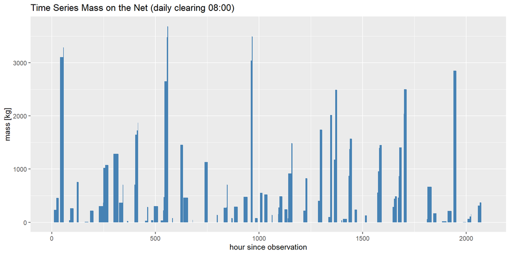

```r
hours_since_observation <- c(1:nrow(net_weigt))
ggplot2::ggplot(data = net_weigt) +
  geom_area(mapping = aes(x = hours_since_observation, y = mass), fill="steelblue") +
  labs(title = "Time Series Mass on the Net (daily clearing 08:00)", x = "hour since observation", y = "mass [kg]")
```

#### 5.2 Mass on the Net Distribution

Now we aim to find a distribution funciton which fits the actual mass data on the net best. In addition, we need the data to be independant. Therefore, to be on the safe side, we just considered the max weight before clearing.

After several tries we did not find out a distribution that fits the weigt on the net well. We decided to try another approach to calculate an appropriate probability that a rock falls through the net.

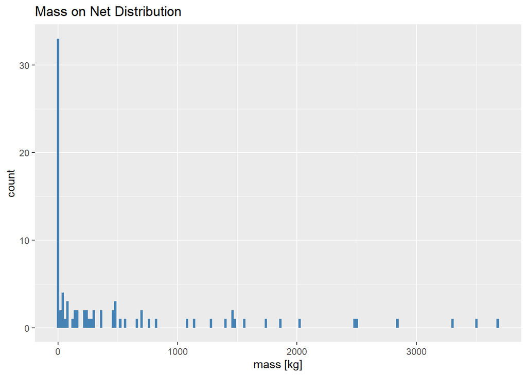

```r
#gets the last cumulative load on the safety net
index_of_clearing_time <- base::match(c(clearing_time), day_times)
if (index_of_clearing_time == 1){
  index_of_clearing_time = length(day_times)
} else {
  index_of_clearing_time = index_of_clearing_time -1
}
cumulative_weight_per_period <- dplyr::filter(net_weigt, time == day_times[(index_of_clearing_time)])

ggplot2::ggplot(data = cumulative_weight_per_period, mapping = aes(x = mass)) +
  geom_histogram(mapping = aes(y = ..count..), binwidth = 20, fill = "steelblue") +
  labs(title = "Mass on Net Distribution", x = 'mass [kg]')
```

### 6. Mass & Speed Distribution

#### 6.1 Mass Distribution out_1

Our next approach is to get the probability with the help of a Monte-Carlo simulation. Therefore, we have to find out the distributions of the weight and speed of a rockfall of each data set `out_1` and `out_2`. In addition, we need the time from an event (rockfall) to the next to set up the simulation.

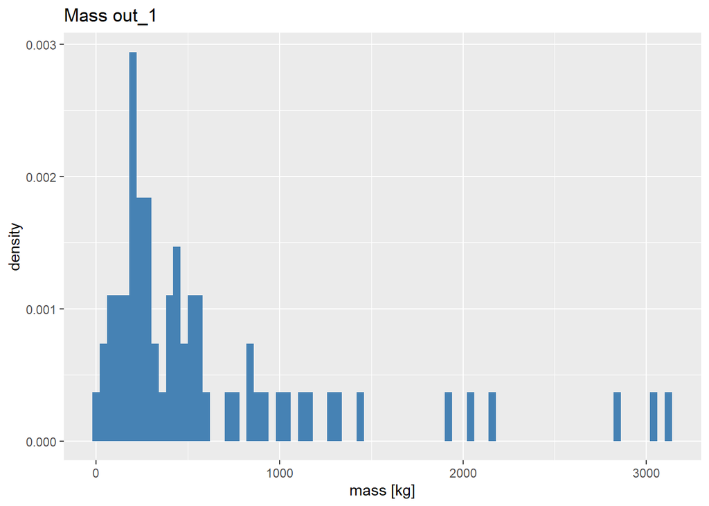

```r
ggplot(out_1, aes(mass)) +
  geom_histogram(aes(y = ..density..), binwidth = 40, fill = "steelblue") +
  labs(title = "Mass out_1", x = "mass [kg]")
```

#### 6.2 Mass Distribution out_2

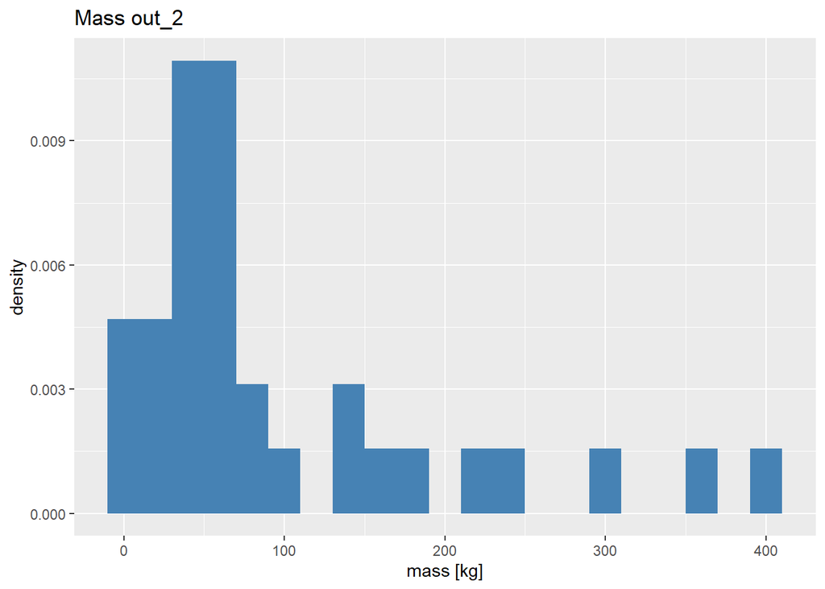

```r
out_2$mass <- base::replace(out_2$mass, out_2$mass == 0, 1) #replace 0 values of the observation to be able to avoid arithmetic issues
ggplot(out_2, aes(mass)) +
  geom_histogram(aes(y = ..density..), binwidth = 20, fill = "steelblue") +
  labs(title = "Mass out_2", x = "mass [kg]")
```

#### 6.3 Mass out_1 Density Function Evaluation

Now we check what distribution fits the mass of `out_1` best. Therefore, we compare exponential, gamma, log-normal and weibull. We can see that the log-normal distribution fits our data best except of the last data point. Even if the last data point is completely not correct estimated, the log normal distribution esitmated the weight higher then the actual weight was, which was estimated more cautiously.

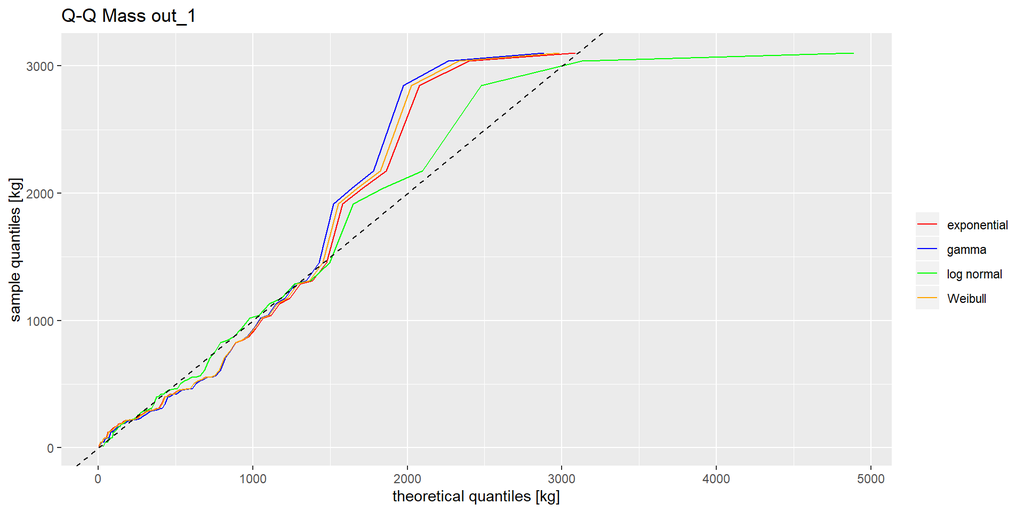

```r
e_fit_mass_out_1 <- fitdistr(out_1$mass, "exponential")
g_fit_mass_out_1 <- fitdistr(out_1$mass, "gamma")
lnrm_fit_mass_out_1 <- fitdistr(out_1$mass, "lognormal")
w_fit_mass_out_1 <- fitdistr(out_1$mass, "weibull")

ggplot(out_1, aes(sample = mass)) +
  stat_qq(distribution = qexp,
          dparams = list(e_fit_mass_out_1$estimate[1]),
          geom = "line",
          aes(color = "exponential")) +
  stat_qq(distribution = qgamma,
          dparams = list(g_fit_mass_out_1$estimate[1], g_fit_mass_out_1$estimate[2]),
          geom = "line",
          aes(color = "gamma")) +
  stat_qq(distribution = qlnorm,
          dparams = list(lnrm_fit_mass_out_1$estimate[1], lnrm_fit_mass_out_1$estimate[2]),
          geom = "line",
          aes(color = "log normal")) +
  stat_qq(distribution = qweibull,
          dparams = list(w_fit_mass_out_1$estimate[1], w_fit_mass_out_1$estimate[2]),
          geom = "line",
          aes(color = "Weibull")) +
  geom_abline(slope = 1, intercept = 0, linetype = "dashed") +
  scale_color_manual(name = "",
                     values = c("exponential" = "red",
                                "gamma" = "blue",
                                "log normal" = "green",
                                "Weibull" = "orange"),
                     breaks = c("exponential",
                                "gamma",
                                "log normal",
                                "Weibull")) +
  labs(title = "Q-Q Mass out_1", x = "theoretical quantiles [kg]", y = "sample quantiles [kg]")
```

#### 6.4 Mass out_2 Density Function Evaluation

Now we aim to find an appropriate distribution funciton for the mass of `out_2`. Therefore, we compare exponential, lognormal and weibull. In regards to the result of the QQ-plot, we decided to consider the exponential distribution function, which is pretty similar distributed compared to the weibull function.

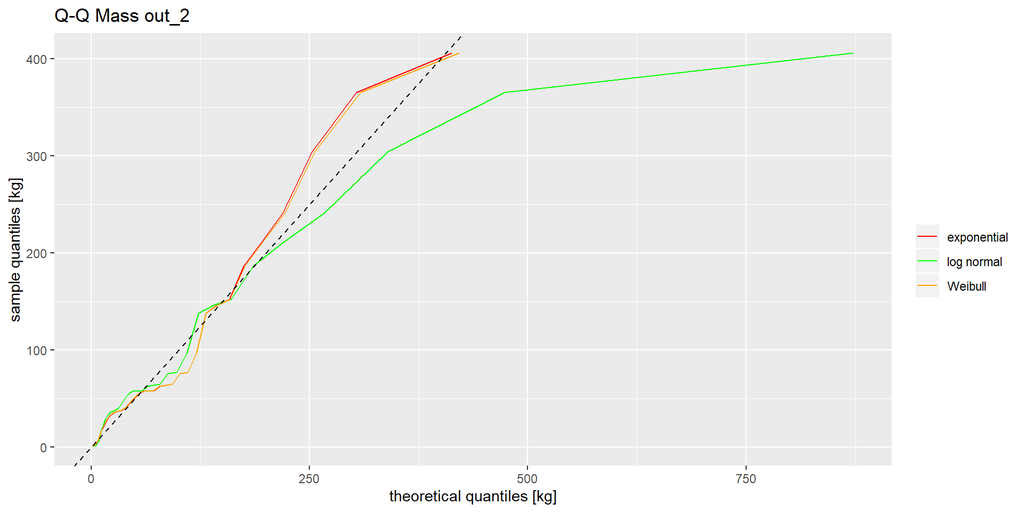

```r
e_fit_mass_out_2 <- fitdistr(out_2$mass, "exponential")
lnrm_fit_mass_out_2 <- fitdistr(out_2$mass, "lognormal")
w_fit_mass_out_2 <- fitdistr(out_2$mass, "weibull")

ggplot(out_2, aes(sample = mass)) +
  stat_qq(distribution = qexp,
          dparams = list(e_fit_mass_out_2$estimate[1]),
          geom = "line",
          aes(color = "exponential")) +
  stat_qq(distribution = qlnorm,
          dparams = list(lnrm_fit_mass_out_2$estimate[1], lnrm_fit_mass_out_2$estimate[2]),
          geom = "line",
          aes(color = "log normal")) +
  stat_qq(distribution = qweibull,
          dparams = list(w_fit_mass_out_2$estimate[1], w_fit_mass_out_2$estimate[2]),
          geom = "line",
          aes(color = "Weibull")) +
  geom_abline(slope = 1, intercept = 0, linetype = "dashed") +
  scale_color_manual(name = "",
                     values = c("exponential" = "red",
                                "gamma" = "blue",
                                "log normal" = "green",
                                "Weibull" = "orange"),
                     breaks = c("exponential",
                                "gamma",
                                "log normal",
                                "Weibull")) +
  labs(title = "Q-Q Mass out_2", x = "theoretical quantiles [kg]", y = "sample quantiles [kg]")
```

#### 6.5 Speed Distribution out_1

Now we are interested in how the speed of `out_1` and `out_2` is distributed.

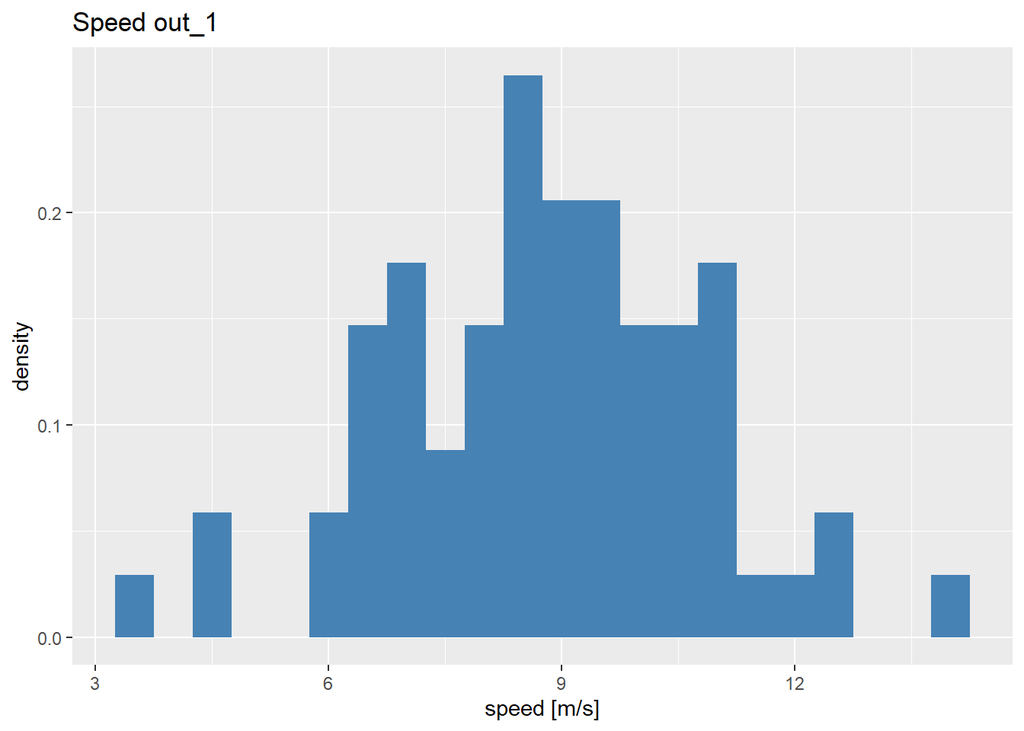

```r
ggplot(out_1, aes(speed)) +
  geom_histogram(aes(y = ..density..), binwidth = 0.5, fill = "steelblue") +
  labs(title = "Speed out_1", x = "speed [m/s]")
```

#### 6.6 Speed Distribution out_2

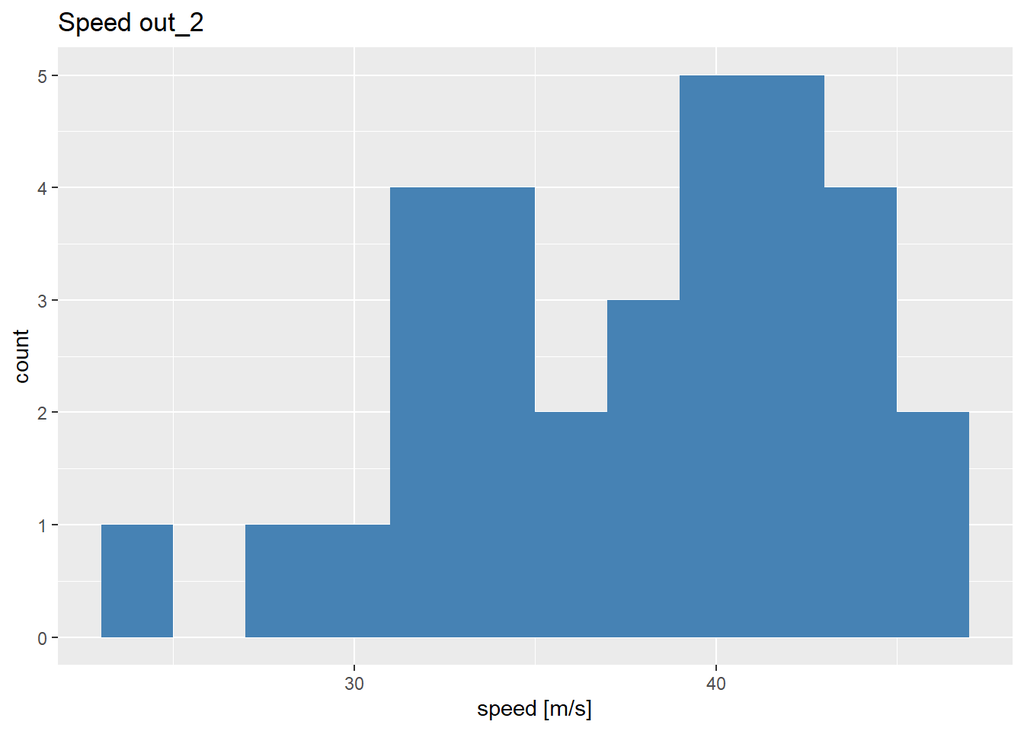

```r
ggplot(out_2, aes(speed)) +
  geom_histogram(aes(y = ..count..), binwidth = 2, fill = "steelblue") +
  labs(title = "Speed out_2", x = "speed [m/s]")
```